# hw_3

Ray Hunter

2023-05-10

```r
knitr::opts_chunk$set(echo = TRUE, warning = FALSE, message = FALSE)

library(tidyverse)
library(janitor)
library(here)
```

### 1

*The data set HW3 data.csv provides price (in $) and quantity (in number of EVs) estimates of demand per year for both DAC and non-DAC groups. Run linear regressions (with an intercept) to estimate the demand curves for DAC and non-DAC consumers. What are 2-3 reasons you can think that may explain the differences in demand you estimate?*

```r
#reading in the data and cleaning names
hw3_data <- read.csv(here("HW3_data.csv")) %>%
  clean_names() %>%
  #renaming price
  rename(price = price_dollars) %>%
  pivot_longer(
    cols= c(q_dac, q_non_dac),
    names_to = "type",
    values_to = "quantity"
  )





#creating an lm of dac
dac_lm <- lm(price ~ quantity, data = filter(hw3_data, type =="q_dac"))

#lm of non dac
non_dac_lm <- lm(price ~ quantity, data = filter(hw3_data, type =="q_non_dac"))

# dac_lm
# non_dac_lm
```

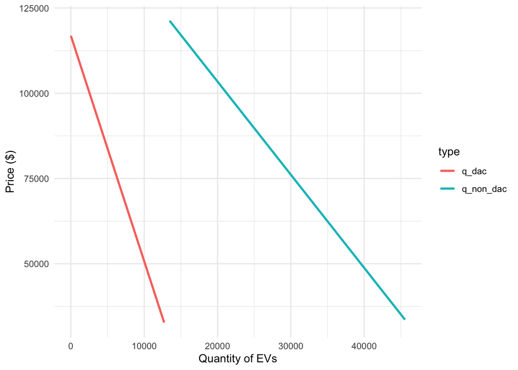

```r
#creating a ggplot of both the lm
ggplot(hw3_data, aes(x= quantity, y = price, color = type)) +
  # geom_smooth(se=FALSE) +
  labs(x = "Quantity of EVs", y = "Price ($)") +
  stat_smooth(method = "lm", se=FALSE) +
  theme_minimal()
```

Non-DAC’s are willing to pay more for electric vehicles to keep their communities clean than DAC’s are. This is likely a result of Non-DAC’s tneding to be composed of wealthier predominately white individuals that have more disposable income. Therefore, they are willing ot pay more to have a clean neighborhood than a DAC community member who makes less money.

### 2

*One kilogram (kg) of lithium is estimated to cause $300 dollars worth of damage in health costs to local communities living near mines. Each EV requires a lithium ion battery containing 63kg of lithium. Assuming there are no other externalities caused by EV production, what is the marginal externality cost per EV produced?*

```r
mec_ev <- 300*63
mec_ev
```

```
## [1] 18900
```

### 3

*What is the aggregate annual demand curve for EVs? What is the supply curve for EVs? What is the “benefit” to consumers under the status quo? What is the “benefit” to producers under the status quo? What is the environmental cost under the status quo?*

### 4

*How is the current consumer benefit divided between DAC and non-DAC consumers?*

### 5

*Derive the optimal EV tax (in $ per vehicle) to internalize the lithium mining externality. Noting that recent research has shown that DACs are far more likely to contain mining activity, assume that the mining externality is borne entirely by the DAC group. What would be the effects of this tax on:*

**(a)** The amount of EVs produced and consumed (b) The price of EVs **(c)** Overall welfare of non-DAC consumers (d) Overall welfare of DAC consumers **(e)** EV producers **(f)** Total environmental damage **(g)** Total tax revenue generated

### 6

*Now, assume that all revenue from the EV tax will be redistributed to the consumers in proportion to their pre-tax consumption. For example, if 80% of the EVs were consumed by non-DAC consumers, then they get 80% of the tax revenue. Additionally, consider that emerging scientific evidence suggests the true environmental damages from lithium mining may be much higher than $300. For a range of values of external costs per kg of lithium ($350, $400, $450, and $500 per kg), calculate the effects of an EV tax on:*

**(a)** Overall welfare of non-DAC consumers **(b)** Overall welfare of DAC consumers **(c)** EV producers

### 7

*Now, consider the fact that the purchase of EVs not only leads to lithium mining, but also helps mitigate climate change by replacing gasoline cars. Suppose that climate change damages fall mostly outside California, to a lesser extent on DAC consumers, and not at all on non-DAC consumers. Qualitatively answer the following (in 1-3 sentences each):*

**(a)** How does the presence of climate change damages from gasoline cars affect the optimal EV tax in California? **(b)** Assuming tax revenue does not get returned to consumers, are non-DAC consumers more or less likely to support this new tax, relative to the tax that only accounts for the mining externality? Why? **(c)** Assuming tax revenue does not get returned to consumers, are DAC consumers more or less likely to support this new tax, relative to the tax that only accounts for the mining externality? Why?